# FIBRA — Founding Partner Invitation

FIBRA Microsite — Wireframe v2 · Data Layer Integrated — July 31 2026 — Not for distribution

S1 — THE VISION

Full-viewport hero. Background: textured linen or artisan-hands video loop (muted, dark). Parallax on scroll.

A PVBLIC Foundation × REIN Hubs Initiative

# The First Fashion & Textile Accelerator in Latin America

FIBRA brings together circular design, textile innovation, and artisan heritage to build the next generation of fashion ventures across five countries.

Become a Founding Partner

Scroll  
to explore

S2 — THE CRISIS · SOURCED DATA

All stats sourced & cited. Hover any source for full citation. Donut chart: where textile waste goes. Bar chart: fiber production growth. Regulation timeline: EU tailwinds.

The Crisis

## Fashion's environmental cost is no longer a footnote

The fashion industry emitted 944 million tonnes of CO₂ in 2023 — a 7.5% spike driven by overproduction and polyester. It consumes 215 trillion litres of water annually, sends 92 million tonnes of textiles to landfill, and loses $150 billion in unrecovered material value every year. Less than 1% of clothing is recycled into new garments.

tonnes CO₂ emitted in 2023 — up 7.5% year-on-year

[Apparel Impact Institute, July 2025](https://apparelimpact.org/resources/fashion-industry-sees-7-emissions-spike-driven-by-overproduction-and-polyester-use/) Source: "Taking Stock of Progress Against the Roadmap to Net Zero 2025" — Apparel sector emissions increased 7.5% in 2023 to 944 million tonnes CO₂e.

tonnes of textile waste produced annually

[UNEP, March 2025](https://www.unep.org/news-and-stories/press-release/unsustainable-fashion-and-textiles-focus-international-day-zero) Source: UNEP International Day of Zero Waste press release. Production doubled between 2000 and 2015 while garment use duration decreased by 36%.

lost annually in unrecovered textile value

[BCG, August 2025](https://www.bcg.com/press/12august2025-fashions-opportunity-reclaim-lost-textile-value) Source: BCG "From Waste to Worth" — 120M metric tons of textile waste globally, 80% goes to landfill/incineration. At 30% recovery, $50B+ in value and 180,000 jobs.

<1%

of clothing recycled into new garments

[Ellen MacArthur Foundation / BCG 2025](https://www.genevaenvironmentnetwork.org/resources/updates/sustainable-fashion/) Source: Ellen MacArthur Foundation, confirmed by BCG 2025. Causes $100B+ annual material loss. Only 8% of textile fibers in 2023 came from recycled sources (UNEP).

litres of water consumed annually

[Quantis, 2018](https://www.genevaenvironmentnetwork.org/resources/updates/sustainable-fashion/) 215 trillion litres — equivalent to 86 million Olympic swimming pools. Fashion is the second-largest consumer of water globally.

of global industrial wastewater from fashion

[World Bank, 2020](https://www.genevaenvironmentnetwork.org/resources/updates/sustainable-fashion/) Approximately 20% of industrial wastewater pollution worldwide originates from the fashion industry's dyeing and treatment processes.

tonnes of microplastics released to oceans yearly

[Ellen MacArthur Foundation](https://www.genevaenvironmentnetwork.org/resources/updates/sustainable-fashion/) 500,000 tonnes of microplastics released into oceans annually from washing synthetic textiles — equivalent to 50 billion plastic bottles.

of global fiber is polyester — driving overproduction

[Apparel Impact Institute, 2025](https://apparelimpact.org/resources/fashion-industry-sees-7-emissions-spike-driven-by-overproduction-and-polyester-use/) Polyester now comprises 57% of total global fiber production. Recycled polyester alternatives remain underutilized.

Where Textile Waste Goes

80% Landfill / Incineration

12% Reused

7% Suitable for Recycling

<1% Recycled to New Fiber

[Source: BCG, "From Waste to Worth," August 2025](https://www.bcg.com/press/12august2025-fashions-opportunity-reclaim-lost-textile-value)

Global Fiber Production (Million Tonnes)

58M

2000

116M

2022

147M

2030 (proj.)

[Source: Geneva Environment Network / Textile Exchange](https://www.genevaenvironmentnetwork.org/resources/updates/sustainable-fashion/)

Regulatory Tailwinds

A wave of EU regulation is creating massive demand for exactly the solutions FIBRA ventures will build — supply chain traceability, circular design, material passports, and producer responsibility systems. LatAm brands exporting to Europe need these capabilities now.

2027

Textile EPR

All EU member states must have textile Extended Producer Responsibility schemes. Brands pay for collection, sorting, and recycling.

2027–28

Digital Product Passport

Every garment sold in the EU needs a QR-linked digital passport with materials, manufacturing, and environmental data.

2028

ESPR Textiles

Mandatory durability, recyclability, and recycled content standards. Ban on destruction of unsold clothing and footwear.

2029

CSDDD

Large brands must identify, prevent, and address human rights and environmental impacts across fashion supply chains.

[Source: Carbonfact EU Regulations Overview, 2026](https://www.carbonfact.com/blog/policy/eu-regulations-for-textile-brands)

S3 — CREDIBILITY

Kerry is the protagonist. High-quality portrait photo. Credential pills show media logos. Below: PVBLIC + REIN impact stats.

Who's Behind FIBRA

## Built on 14 years of fashion, impact, and global policy

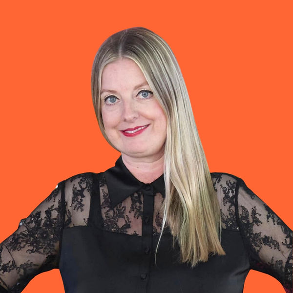

### Kerry Bannigan

Managing Director, PVBLIC Foundation · Founder, Conscious Fashion Campaign

British social entrepreneur, advocate, and advisor who has spent over 14 years pioneering fashion and sustainability initiatives at the intersection of the United Nations, global media, and the fashion industry. Founding member and Executive Producer of the SDG Media Zone. Former founder of the Fashion Impact Fund, which supported 8 women-led organizations across 6 countries and equipped 124 participants with textile and design skills.

Earth Day Ambassador. Swarovski Foundation Creatives for Our Future advocate. Featured across international media for her work connecting fashion to the Sustainable Development Goals.

BBC Forbes Vogue Business WWD CFDA ELLE SDG Media Zone UN DESA

#### PVBLIC Foundation

Billion people reached via the SDG Media Zone in partnership with the UN Department of Global Communications, across 80 countries.

1,200+

#### REIN Hubs

Entrepreneurs supported across Colombia, Peru, Guatemala, Costa Rica, and El Salvador. 222 startups incubated. $23M+ capital raised. 1,500+ green jobs created.

#### Fashion Impact Fund Legacy

Women equipped with textile and design skills across 8 grantee organizations in Africa, South Asia, the Caribbean, UK, and USA (2022–2026).

S4 — THE WHITE SPACE

Visual "gap" diagram. Right column items now reference specific EU regulations from the data layer.

The White Space

## Latin America has the talent. It lacks the infrastructure.

Fashion accelerators exist in Europe and North America. LatAm sustainable fashion ventures exist in isolation. No program connects them to capital, mentorship, and markets at regional scale — while a wave of EU regulation creates urgent demand for the solutions they're building.

#### What Exists

- Circular fashion founders in every country
- Bio-material innovation (pineapple fiber, cacao, recycled textiles)
- Artisan heritage and indigenous textile traditions
- Women-majority textile workforce seeking formalization
- EU Digital Product Passport mandate from 2027 creating export demand

→

#### What's Missing

- Pan-regional acceleration infrastructure
- Fashion-specific investor pipeline for LatAm
- Gender-lens M&E framework for fashion ventures
- Bridge from artisan production to formal markets
- EU compliance readiness for LatAm brands (ESPR, EPR, DPP)

FIBRA fills this gap.

The first pan-regional, impact-focused fashion accelerator in Latin America.

The Talent

## The founders already building the future of fashion

These ventures are in the REIN Hubs pipeline today. FIBRA will accelerate the next generation alongside them.

[figure not shown]

Track 1 · Circular & Sustainable Fashion

### REEMADE SAS

Founded by Ximena Vélez Robledo · Medellín, Colombia

Circular design studio upcycling hard-to-recycle materials — truck tarps, tires, industrial textiles, and coffee waste — into luxury-grade fashion accessories. Their Biomera collection debuted at Colombiamoda 2026.

B2B + Consumer · Circular Manufacturing

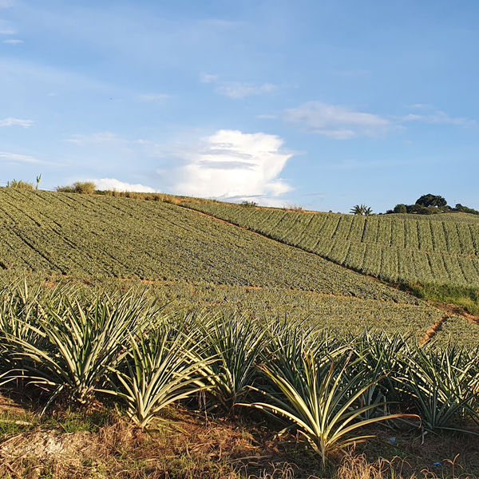

Track 2 · Textile Innovation

### Green Leaf Natural Fibers

Co-Founded by Jennifer González · Santander, Colombia (est. 2021)

Transforms pineapple crop waste into plant-based textile fibers for fashion, construction, and design. Bridges agricultural waste reduction, rural women's employment, and bio-material innovation.

Bio-materials · Rural Women · Agri-Waste Upcycling

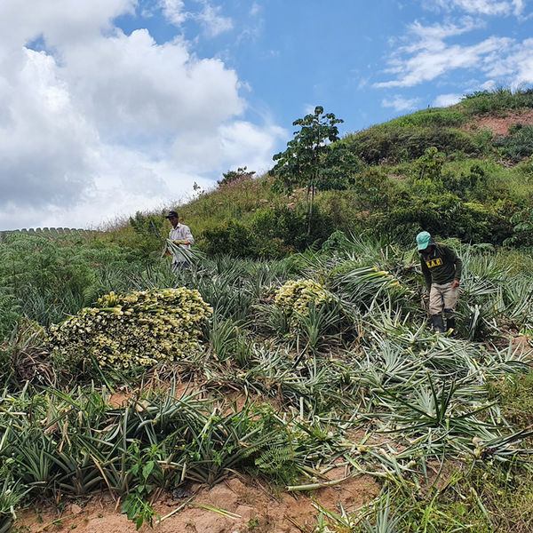

Track 2 · Textile Innovation

### Green Leaf — From Field to Fiber

Pineapple leaf harvesting · Santander, Colombia

Workers harvest pineapple leaves that would otherwise be burned or left to rot. Each hectare of pineapple generates 40 tonnes of leaf waste annually — Green Leaf turns this into textile-grade fiber, creating rural employment in the process.

Supply Chain Origin · Job Creation · Zero Waste Agriculture

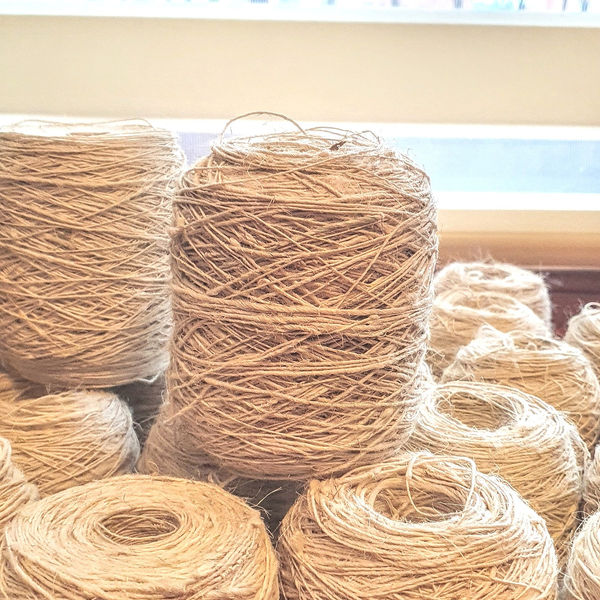

Track 2 · Textile Innovation

### Green Leaf — The Product

Pineapple fiber yarn · Ready for weaving

Raw pineapple leaf fiber processed into yarn spools ready for the textile industry. This is what EU Digital Product Passport-ready, fully traceable material looks like — from field to fabric, every step documented.

DPP-Ready · Traceable · Natural Fiber

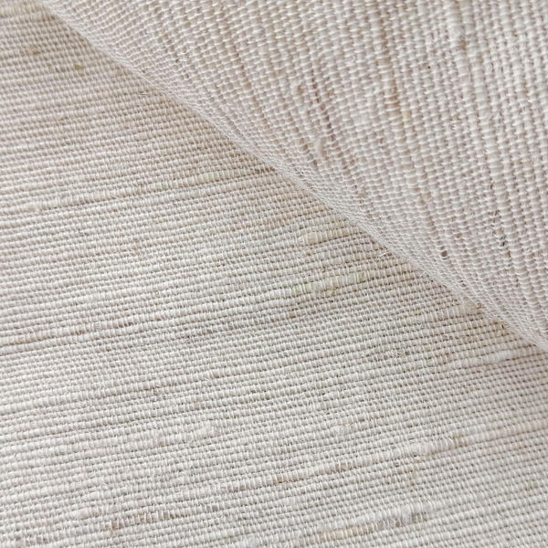

Track 2 · Textile Innovation

### Green Leaf — Finished Fabric

Woven pineapple fiber textile · Market-ready

The finished product: woven pineapple fiber fabric with a natural linen-like texture. Suitable for fashion, interiors, and accessories. This is the kind of innovation that FIBRA will bring to market at scale.

Market-Ready · Fashion-Grade · Sustainable Textile

S5 — THE PROGRAM

Track cards with hover. Timeline with animated dots. Each track links to a real REIN-pipeline venture.

The Program

## Four tracks. Ten ventures. Five countries.

A 16-week acceleration cohort launching Q1 2027, delivered through REIN Hubs' infrastructure across Colombia, Peru, Guatemala, Costa Rica, and El Salvador.

01

Circular & Sustainable Fashion

Circular economy models, regenerative materials, waste-to-product manufacturing, closed-loop design systems.

↳ Example: REEMADE SAS (Colombia) — Upcycling industrial waste into fashion products

02

Textile Innovation

Bio-materials, plant-based fibers, supply chain technology, EU compliance readiness for emerging brands.

↳ Example: Green Leaf (Colombia) — Pineapple waste to textile fiber

03

Artisan Heritage to Market

Formalising indigenous and craft-based businesses, connecting traditional techniques to contemporary markets.

↳ Example: Sourcing from 5 countries with distinct artisan traditions

04

Supply Chain Transparency

Traceability platforms, ethical sourcing verification, B2B SaaS for fashion supply chain management.

↳ Example: TR Global / SLOW (Colombia) — Textile waste management & sorting

Sep 2026

UNGA 81 Launch  
& Positioning

Oct–Dec 2026

Fundraising  
& Partner Close

Q1 2027

Cohort 1  
Launch

Q2 2027

Demo Day  
& Impact Report

S6 — SOCIAL PROOF

Embed the July 23 LinkedIn post (Buffer) as a styled card. Links to live post.

From the Field

## Already building the ecosystem

REIN Hubs and PVBLIC Foundation are already working with circular fashion innovators across Latin America. Here's what that looks like.

C

#### CleantechHUB

LinkedIn · July 23, 2026

This is what real impact looks like! Entrepreneurs across Latin America turning agricultural and industrial waste into next-generation materials for fashion and beyond.  
Through REIN Hubs, the nature-based entrepreneurship platform we run together with PVBLIC Foundation across Colombia, Guatemala, Costa Rica, Peru and El Salvador, we see these innovators up close every day...

↗ View on LinkedIn

S7 — THE INVITATION

Interactive tier tabs. Click to switch between $50k and $25k. Benefits grid with check marks.

Founding Partner Invitation

## Shape the future of fashion in Latin America

A limited number of Founding Partner positions are available for FIBRA's inaugural cohort. Your contribution launches the first pan-regional fashion accelerator on the continent — and your name is part of that story from day one.

$50,000

Named Track Sponsor — e.g. "The [Your Name] Artisan Heritage Track"

#### Visibility & Brand

- ✓ Named track association
- ✓ Logo on all FIBRA materials & website
- ✓ Featured in PVBLIC + CTH + REIN newsletters
- ✓ Social media across all partner channels
- ✓ SDG Media Zone panel branding

#### Access & Intelligence

- ✓ Advisory Circle seat — quarterly briefings
- ✓ Early Demo Day deal flow access
- ✓ Curated venture introductions
- ✓ Annual impact report with venture-level data
- ✓ Gender-lens M&E reporting

#### Storytelling & Experiences

- ✓ Co-branded impact story (video or feature)
- ✓ Speaking slot at FIBRA Demo Day
- ✓ Press release inclusion
- ✓ PVBLIC UNGA convening invitations
- ✓ Optional REIN Hub site visit

$25,000

Core Program Supporter — Mentorship, Curriculum & Impact Measurement

#### Visibility & Brand

- ✓ Logo on FIBRA website & materials
- ✓ Featured in partner newsletters
- ✓ Social media acknowledgment

#### Access & Intelligence

- ✓ Quarterly impact updates
- ✓ Demo Day invitation + early access
- ✓ Annual impact report

#### Storytelling & Experiences

- ✓ Named mention in press releases
- ✓ Quote opportunity in launch comms
- ✓ PVBLIC UNGA convening invitations

S8 — THE MOMENT

Clean close. UNGA badge anchors urgency. Single CTA. Kerry's contact info below.

UNGA 81 · New York · September 2026

## This is the moment to build something that hasn't existed before

FIBRA launches at UNGA 81 and Climate Week NYC. Founding Partners are announced from the SDG Media Zone stage. Cohort 1 opens Q1 2027. The window to be part of the founding story is now.

Become a Founding Partner